# Lecture 12

## References

- Numerical Python: Scientific Computing and Data Science Applications with Numpy, SciPy and Matplotlib (2nd Edition), Robert Johansson.

## This Lecture

- Numerical integration using **scipy.integrate** submodule

## Multiple Integration with Scipy

- **dblquad**: can be used to evaluate $\displaystyle\int_a^b\int_c^df(x,y)dxdy$
- **tplquad**: can be used to evaluate $\displaystyle\int_a^b\int_c^d\int_e^ff(x,y,)dxdydz$
- **nquad**: can be used to evaluate $\displaystyle\int\dots\int_Df(\mathbf{x})d\mathbf{x}$

These functions are wrappers around the single-variable quadrature function **quad**, which is called repeatedly along each dimension of the multiple integral

```python
#import modules
import numpy as np
from scipy import integrate
import matplotlib.pyplot as plt
```

**Example**: evaluate $$ \int_{-1}^1\int_{-1}^1 \sin(2\pi x)\sin(2\pi y)dxdy = 0 $$

```python
f = lambda x,y: np.sin(2.*np.pi*x)* np.sin(2.*np.pi*y)
```

```python
val,err=integrate.dblquad(f,-1,1,-1,1)
print('val=%e\nerr=%e'%(val,err))
```

```
val=0.000000e+00
err=1.380809e-14
```

We can also compute integrals of the following form: $$ \displaystyle\int_a^b\int_{g(x)}^{h(x)}f(x,y)dxdy $$

**Example**: evaluate $$ \int_{0}^1\int_{g(x)}^{h(x)} e^{-x^2-y^2} dxdy $$

We consider two cases:

1. $g(x)=0$ and $h(x)=1$, i.e., $\displaystyle \int_{0}^1\int_{0}^{1} e^{-x^2-y^2} dxdy $
2. $g(x)=x-1$ and $h(x)=1-x$, i.e., $\displaystyle \int_{0}^1\int_{x-1}^{1-x} e^{-x^2-y^2} dydx $

First, let's see what we are doing here

```python
# integrand
f = lambda x,y: np.exp(-x**2-y**2)

x=np.linspace(-1.,1.,100)
y=x
X,Y=np.meshgrid(x,y)  # square grid [-1,1]x[-1,1]

# integral limit along x dimension
a=0.
b=1.
# case 1
g1 =  lambda x: 0.
h1 =  lambda x: 1.
val1,err1=integrate.dblquad(f,a,b,g1,h1)

# case 2
g2 =  lambda x: x-1.
h2 =  lambda x: 1.-x
val2,err2=integrate.dblquad(f,a,b,g2,h2)
```

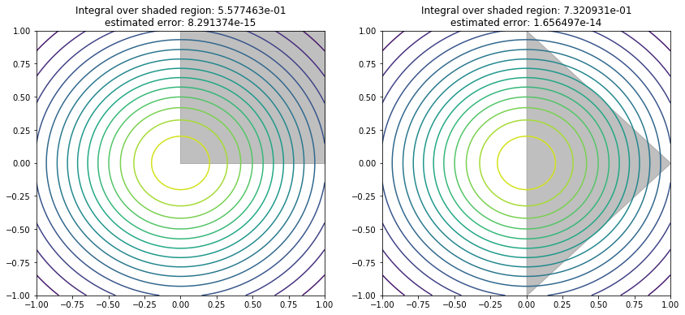

```python
xint=np.linspace(a,b,10)
fig,axes=plt.subplots(1,2,figsize=(14,6))
axes[0].contour(X,Y,f(X,Y),15)
axes[0].fill_between(xint,g1(xint),h1(xint),color='grey',alpha=0.5)    # integral region
axes[0].set_title('Integral over shaded region: %e\nestimated error: %e'%(val1,err1))



axes[1].contour(X,Y,f(X,Y),15)
axes[1].fill_between(xint,g2(xint),h2(xint),color='grey',alpha=0.5)    # integral region
axes[1].set_title('Integral over shaded region: %e\nestimated error: %e'%(val2,err2))



plt.show()
```

**Example**: evaluate $$ \int_{0}^1\int_{g(x)}^{h(x)}\int_{q(x,y)}^{r(x,y)} e^{-x^2-y^2-z^2} dzdydx $$

We consider the easiest case: $$ \int_{0}^1\int_{0}^{1}\int_{0}^{1} e^{-x^2-y^2-z^2} dzdydx $$

```python
def f(x,y,z):
    return np.exp(-x**2-y**2-z**2)

a,b=0,1
g,h=lambda x:0, lambda x:1
q,r=lambda x,y:0, lambda x,y:1


integrate.tplquad(f,a,b,g,h,q,r)
```

```
(0.4165383858866382, 8.291335287314424e-15)
```

Integrate over a sphere:

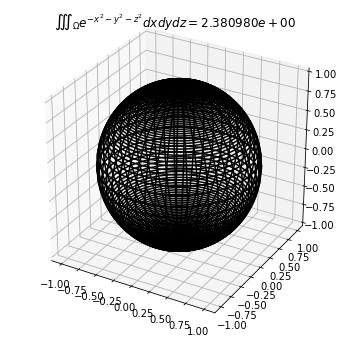

```python
def f(x,y,z):
    return np.exp(-x**2-y**2-z**2)

a,b=-1,1
g=lambda x:-np.sqrt(1.-x**2)
h=lambda x:np.sqrt(1.-x**2)
q=lambda x,y:-np.sqrt(1.-x**2-y**2)
r=lambda x,y:np.sqrt(1.-x**2-y**2)



# integrate over this region
val,err=integrate.tplquad(f,a,b,g,h,q,r)


# plot region
# Create the mesh in polar coordinates and compute corresponding Z.
R = np.linspace(0, 1, 100)
P = np.linspace(0, 2*np.pi, 100)
R, P = np.meshgrid(R, P)
X=R*np.cos(P)
Y=R*np.sin(P)
Z1 = -np.sqrt(1-R**2)
Z2 = np.sqrt(1-R**2)


from mpl_toolkits.mplot3d import Axes3D
fig = plt.figure(figsize=(6,6))
ax = plt.axes(projection='3d')
ax.plot_wireframe(X, Y, Z1,color='k')
ax.plot_wireframe(X, Y, Z2,color='k')



ax.set_title(r'$\iiint_\Omega e^{-x^2-y^2-z^2} dxdydz = %e$'%val )

plt.show()
```

We can also compute integrals of the following form: $$ \displaystyle\int\dots\int_Df(\mathbf{x})d\mathbf{x} $$

**Example**: evaluate $$ \int_{0}^1\dots\int_{0}^1 e^{-x_1^2-x_2^2-\dots -x_n^2} dx_1dx_2\dots dx_n $$

How to use:

**integrate.nquad(f,[(a1,b1),(a_2,b2),....,(an,bn)])**

```python
def f(*args):  # arbitrary number of inputs: *args unpack the input args list
    return np.exp(-np.sum(np.array(args )**2))
```

```python
%time integrate.nquad(f,[(0,1)]*1)
```

```
CPU times: user 567 µs, sys: 16 µs, total: 583 µs
Wall time: 594 µs
```

```
(0.7468241328124271, 8.291413475940725e-15)
```

```python
%time integrate.nquad(f,[(0,1)]*2)
```

```
CPU times: user 4.66 ms, sys: 11 µs, total: 4.67 ms
Wall time: 4.68 ms
```

```
(0.5577462853510337, 8.291374381535408e-15)
```

```python
%time integrate.nquad(f,[(0,1)]*3)
```

```
CPU times: user 103 ms, sys: 2.34 ms, total: 106 ms
Wall time: 105 ms
```

```
(0.4165383858866382, 8.291335287314424e-15)
```

```python
%time integrate.nquad(f,[(0,1)]*4)
```

```
CPU times: user 1.96 s, sys: 8.76 ms, total: 1.97 s
Wall time: 1.97 s
```

```
(0.31108091882287664, 8.291296193277774e-15)
```

```python
%time integrate.nquad(f,[(0,1)]*5)
```

```
CPU times: user 41.8 s, sys: 156 ms, total: 42 s
Wall time: 42.1 s
```

```
(0.23232273743438786, 8.29125709942545e-15)
```

We see that the complexity of a multiple integral grows quickly!